# Week 3: Normalizing counts and selecting genes with SCTransform

Kevin Z. Lin

2026-08-09

# 1 Overview

This tutorial was made from the Seurat `SCTransform` vignette, https://satijalab.org/seurat/articles/sctransform_vignette, the cell cycle vignette, https://satijalab.org/seurat/articles/cell_cycle_vignette.html, and Hafemeister & Satija (2019).

Week 1 normalized with three commands and defended none of them:

```r
pbmc <- NormalizeData(pbmc)        # divide by library size, log
pbmc <- FindVariableFeatures(pbmc) # keep 2,000 genes
pbmc <- ScaleData(pbmc)            # centre and scale each gene
```

This tutorial is about what those three lines are for, why the standard version of them is unsatisfying, and what `SCTransform` — a single command that replaces all three — does instead.

## 1.1 What normalization is actually for

A cell with 5,000 UMIs and a cell with 500 UMIs are not ten times different in biology; one was sequenced more deeply. Every normalization is an attempt to remove that nuisance so that what remains is comparable across cells.

The Week 1 approach divides each cell’s counts by its total and takes a log. It is simple and it works well enough to have carried the field for years. Its problem is an assumption hiding in the division: that a gene’s expression scales with sequencing depth *in the same way for every gene*. It does not. Highly expressed genes and barely detected genes have very different count-depth relationships, and after log-normalization the low-expression genes keep more depth-driven variance than the high-expression ones.

The consequence is the thing you actually care about: **variable gene selection gets distorted.** Genes look variable because they are abundant, not because they distinguish cell types.

## 1.2 What SCTransform does instead

`SCTransform` fits a regularized negative binomial regression for each gene, with sequencing depth as the predictor, and keeps the **Pearson residuals** — how far each cell’s count for that gene is from what depth alone would predict, in units of the model’s own standard deviation.

That single change buys three things:

- **Depth is removed per gene**, according to that gene’s fitted relationship, rather than by one global division.
- **The residual is already a z-score-like quantity**, so no separate `ScaleData()` step is needed.
- **Variable genes fall out of the model.** A gene is interesting if its residual variance is high — if cells disagree about it more than the noise model says they should. This is a principled criterion rather than a mean-variance heuristic.

“Regularized” is doing real work in that description. Fitting an independent negative binomial per gene on a few thousand cells overfits badly, so the per-gene parameters are smoothed against genes of similar abundance. That smoothing is why the method is stable on genes detected in a handful of cells.

The plan:

| Stage | What it produces | Function |
| --- | --- | --- |
| 1. Measure the nuisances | `percent.mt`, and a cell cycle score per cell | `PercentageFeatureSet()`, `CellCycleScoring()` |
| 2. Normalize, select, scale | One `SCT` assay with Pearson residuals and 3,000 variable genes | `SCTransform()` |
| 3. Reduce and embed | A PCA on the residuals, and a UMAP | `RunPCA()`, `RunUMAP()` |
| 4. Check the regression worked | `percent.mt` should have no structure left on the UMAP | `FeaturePlot()` |
| 5. Interrogate the gene list | Why *these* 3,000 genes and not the loudest ones | `ggplot2` |
| 6. Force genes in | Residuals for a gene set you care about regardless of rank | `residual.features` |

> **Where this sits in the workshop.** This is the Week 3 normalization and gene-selection material. The companion Week 3 tutorial, *Batch effects and integration in Seurat v5*, runs the log-normalization route on a multi-batch dataset; `IntegrateLayers()` accepts `normalization.method = "SCT"`, so the two compose. Clustering on top of what we build here, and differential expression, are **Week 4**.

# 2 Setting up

```r
# install.packages("sctransform")
# install.packages("scCustomize")
# install.packages("ggrepel")
# devtools::install_github("satijalab/seurat-data")
```

```r
library(Matrix)
library(Seurat)
library(SeuratData)
library(SeuratObject)
library(scCustomize)
library(ggplot2)
library(ggrepel)
```

```r
rm(list = ls())
```

`SCTransform` sends large objects to parallel workers, and Seurat’s default size limit is smaller than what this needs. Raising it up front avoids an error that does not mention normalization at all:

```r
options(future.globals.maxSize = 8000 * 1024^2)
```

# 3 The data

We use **pbmc3k**, the same 2,700 peripheral blood cells as Week 1, so that the difference you see is the method rather than the dataset.

```r
# SeuratData::InstallData("pbmc3k")
```

```r
pbmc <- SeuratData::LoadData("pbmc3k")
pbmc
```

```
## An object of class Seurat
## 13714 features across 2700 samples within 1 assay
## Active assay: RNA (13714 features, 0 variable features)
##  2 layers present: counts, data
```

13,714 genes across 2,700 cells. This copy also ships the curated cell type labels from the Seurat tutorials, which will be useful at the end as an independent check on what our gene selection produced:

```r
table(pbmc$seurat_annotations, useNA = "ifany")
```

```
##
##  Naive CD4 T Memory CD4 T   CD14+ Mono            B        CD8 T FCGR3A+ Mono
##          697          483          480          344          271          162
##           NK           DC     Platelet         <NA>
##          155           32           14           62
```

```r
count_mat <- SeuratObject::LayerData(pbmc, assay = "RNA", layer = "counts")
dim(count_mat)
```

```
## [1] 13714  2700
```

```r
count_mat[11:20, 1:10]
```

```
## 10 x 10 sparse Matrix of class "dgCMatrix"
```

```
##
## RP11-54O7.11 . . . . . . . . . .
## ISG15        . . 1 9 . 1 . . . 3
## AGRN         . . . . . . . . . .
## C1orf159     . . . . . . . . . .
## TNFRSF18     . 2 . . . . . . . .
## TNFRSF4      . . . . . . . . 1 .
## SDF4         . . 1 . . . . . . .
## B3GALT6      . . . . . . 1 . . .
## FAM132A      . . . . . . . . . .
## UBE2J2       . . . . . . . . 1 .
```

Mostly dots. In a sparse matrix a `.` is a structural zero, and the fact that almost every entry is one is the central statistical fact about this data type — it is why a normal-theory method applied to raw counts behaves badly, and why the negative binomial shows up.

> **`layer = "counts"`, in quotes.** Writing `layer = counts` without them makes R look for an object named `counts` and fail with `object 'counts' not found`. It is an easy slip because `assay` and `layer` both take strings that look like slot names.

# 4 The two nuisances we will regress out

`SCTransform` can regress additional covariates alongside sequencing depth. We will hand it two. Both need to be computed first, and both are worth understanding before they are used.

## 4.1 Mitochondrial content

A cell whose membrane broke before capture loses cytoplasmic mRNA but keeps what is inside its mitochondria, so a high mitochondrial fraction is the standard signature of a dying cell.

```r
genes <- SeuratObject::Features(pbmc)
grep("^MT-", genes, value = TRUE)
```

```
##  [1] "MT-ND1"  "MT-ND2"  "MT-CO1"  "MT-CO2"  "MT-ATP8" "MT-ATP6" "MT-CO3"
##  [8] "MT-ND3"  "MT-ND4L" "MT-ND4"  "MT-ND5"  "MT-ND6"  "MT-CYB"
```

Thirteen genes, which is the whole mitochondrial genome. The `^MT-` pattern works because these symbols are standardized — but only for **human gene symbols**. Mouse uses `^mt-`, and a matrix with Ensembl IDs for row names has no `MT-` anything, in which case `PercentageFeatureSet()` cheerfully returns 0% for every cell and you never learn that the filter did nothing. Print the gene list before you trust the number.

```r
pbmc <- Seurat::PercentageFeatureSet(pbmc,
                                     pattern = "^MT-",
                                     col.name = "percent.mt")
quantile(pbmc$percent.mt)
```

```
##        0%       25%       50%       75%      100%
##  0.000000  1.537264  2.030801  2.643177 22.569028
```

A median of 2.0% and a maximum of 22.6%. These are healthy fresh PBMCs; nuclei from frozen post-mortem brain look very different, which is the Week 2 discussion.

## 4.2 Cell cycle

Proliferating cells express hundreds of cycle-related genes together, which can dominate the variable gene list and split one cell type into two clusters that differ only by phase. `CellCycleScoring()` scores each cell against two curated gene sets and calls a phase.

```r
pbmc <- Seurat::NormalizeData(pbmc)
```

This `NormalizeData()` call is not part of the SCTransform route and does not survive into it. `CellCycleScoring()` reads the `data` layer, so the layer has to be populated before it runs; `SCTransform()` later builds its own assay and ignores this one.

```r
s_genes <- cc.genes$s.genes
g2m_genes <- cc.genes$g2m.genes

length(s_genes)
```

```
## [1] 43
```

```r
length(g2m_genes)
```

```
## [1] 54
```

```r
sum(s_genes %in% genes)
```

```
## [1] 36
```

```r
sum(g2m_genes %in% genes)
```

```
## [1] 44
```

Seurat ships these lists in `cc.genes`. Of the 43 S-phase and 54 G2M genes, 36 and 44 are present here — the rest are absent from this matrix, and `CellCycleScoring()` will warn about each one.

Seurat also ships a second copy of these lists with modernized symbols, where `MLF1IP` has become `CENPU` and `FAM64A` has become `PIMREG`:

```r
sum(cc.genes.updated.2019$s.genes %in% genes)
```

```
## [1] 38
```

```r
sum(cc.genes.updated.2019$g2m.genes %in% genes)
```

```
## [1] 43
```

> **Gene symbols have a vintage, and newer is not automatically better.** The updated lists match 38 S and 43 G2M genes here, against 36 and 44 for the original — two more S-phase genes, but one G2M gene *fewer*. pbmc3k was annotated with an old reference, so some of the modern symbols (`PIMREG`, `JPT1`) are absent from this matrix while the old ones they replaced are present. The rule is to match the vintage of your gene sets to the vintage of the annotation your counts were built against, and to check the overlap rather than assume it.

```r
pbmc <- Seurat::CellCycleScoring(pbmc,
                                 s.features = s_genes,
                                 g2m.features = g2m_genes)
table(pbmc$Phase)
```

```
##
##   G1  G2M    S
## 1232  456 1012
```

```r
quantile(pbmc$S.Score)
```

```
##          0%         25%         50%         75%        100%
## -0.08150692 -0.03962714 -0.01265061  0.01843997  0.70840258
```

```r
quantile(pbmc$G2M.Score)
```

```
##           0%          25%          50%          75%         100%
## -0.113134835 -0.066818941 -0.037602198 -0.003773844  0.805765881
```

Now stop and read that table sceptically, because it is the most instructive thing in this section.

**456 of 2,700 resting blood cells are called G2M.** Circulating PBMCs are overwhelmingly non-dividing. There are not 456 mitotic cells in this sample.

The quantiles explain what happened. Both scores are negative through the median — `S.Score` −0.013, `G2M.Score` −0.038 — meaning the typical cell expresses the cycle gene sets *less* than the background of comparably abundant genes. `CellCycleScoring()` nonetheless assigns every cell a phase, by taking whichever of the two scores is larger and calling `G1` only when both are negative. With no real signal, the call is decided by noise.

> **The lesson, which matters more for this room than for PBMCs.** Post-mitotic tissue — brain, above all — has no cell cycle to speak of. Run `CellCycleScoring()` on nuclei from post-mortem cortex and you will still get a confident-looking `Phase` column, and regressing out `S.Score` and `G2M.Score` will still change your embedding, because you are regressing out a noise variable. Check the score distributions before deciding a covariate is real. If both scores sit near zero, the honest move is to leave them out.

> We keep them here because the point of this tutorial is to show the mechanism, and because it is a faithful reproduction of what the vignette does. It is not an endorsement for your data.

```r
head(pbmc@meta.data)
```

```
##                orig.ident nCount_RNA nFeature_RNA seurat_annotations percent.mt
## AAACATACAACCAC     pbmc3k       2419          779       Memory CD4 T  3.0177759
## AAACATTGAGCTAC     pbmc3k       4903         1352                  B  3.7935958
## AAACATTGATCAGC     pbmc3k       3147         1129       Memory CD4 T  0.8897363
## AAACCGTGCTTCCG     pbmc3k       2639          960         CD14+ Mono  1.7430845
## AAACCGTGTATGCG     pbmc3k        980          521                 NK  1.2244898
## AAACGCACTGGTAC     pbmc3k       2163          781       Memory CD4 T  1.6643551
##                     S.Score   G2M.Score Phase
## AAACATACAACCAC  0.087612123 -0.03975945     S
## AAACATTGAGCTAC -0.032186625 -0.04592384    G1
## AAACATTGATCAGC -0.003229535  0.08708570   G2M
## AAACCGTGCTTCCG  0.047136585  0.01114362     S
## AAACCGTGTATGCG -0.035409519  0.05106560   G2M
## AAACGCACTGGTAC -0.042155887 -0.07677790    G1
```

# 5 Running SCTransform

One command replaces `NormalizeData()`, `FindVariableFeatures()` and `ScaleData()`.

```r
set.seed(10)
pbmc_sct <- Seurat::SCTransform(pbmc,
                                vars.to.regress = c("percent.mt",
                                                    "S.Score",
                                                    "G2M.Score"),
                                variable.features.n = 3000,
                                seed.use = 10,
                                verbose = FALSE)
pbmc_sct
```

```
## An object of class Seurat
## 26286 features across 2700 samples within 2 assays
## Active assay: SCT (12572 features, 3000 variable features)
##  3 layers present: counts, data, scale.data
##  1 other assay present: RNA
```

`vars.to.regress` adds those columns to the model as covariates, so the residual that comes out is what is left after depth, mitochondrial fraction and cycle score have all been accounted for. `variable.features.n = 3000` asks for 3,000 genes rather than the 2,000 that `FindVariableFeatures()` defaults to; SCT residuals support a larger list without it filling up with noise.

## 5.1 Reading the object

The object now has two assays and the active one has changed:

```r
SeuratObject::Assays(pbmc_sct)
```

```
## [1] "RNA" "SCT"
```

```r
SeuratObject::DefaultAssay(pbmc_sct)
```

```
## [1] "SCT"
```

> **`SCTransform()` silently switches `DefaultAssay` to `SCT`.** Every subsequent command that does not name an assay now operates on residuals rather than counts. That is usually what you want for PCA and plotting, and emphatically not what you want for differential expression, which needs the `RNA` assay. The original counts are still there, untouched, under `pbmc_sct[["RNA"]]`.

Three layers, and they are not the three you might expect:

```r
SeuratObject::Layers(pbmc_sct[["SCT"]])
```

```
## [1] "counts"     "data"       "scale.data"
```

```r
dim(SeuratObject::LayerData(pbmc_sct, layer = "counts", assay = "SCT"))
```

```
## [1] 12572  2700
```

```r
dim(SeuratObject::LayerData(pbmc_sct, layer = "data", assay = "SCT"))
```

```
## [1] 12572  2700
```

```r
dim(SeuratObject::LayerData(pbmc_sct, layer = "scale.data", assay = "SCT"))
```

```
## [1] 3000 2700
```

Two numbers there deserve attention.

**12,572, not 13,714.** SCTransform drops genes detected in too few cells — the `min_cells` argument, default 5 — because there is not enough information to fit a model for them. 1,142 genes disappeared, and no warning was printed. If a gene you care about is missing downstream, this is usually why.

**3,000 rows in `scale.data`, not 12,572.** The Pearson residuals are only retained for the variable features. This is a deliberate memory trade-off, and it is the reason the next section’s distinction between “has a residual” and “is a variable feature” matters.

```r
data_mat <- SeuratObject::LayerData(pbmc_sct, layer = "data", assay = "SCT")
round(data_mat[1:10, 1:10], 3)
```

```
## 10 x 10 sparse Matrix of class "dgCMatrix"
```

```
##
## AL627309.1    . . .     .     . .     . . . .
## RP11-206L10.2 . . .     .     . .     . . . .
## LINC00115     . . .     .     . .     . . . .
## NOC2L         . . .     .     . .     . . . .
## KLHL17        . . .     .     . .     . . . .
## PLEKHN1       . . .     .     . .     . . . .
## HES4          . . .     .     . .     . . . .
## ISG15         . . 0.693 2.197 . 0.693 . . . 1.792
## AGRN          . . .     .     . .     . . . .
## C1orf159      . . .     .     . .     . . . .
```

The `data` layer is just `log1p()` of the `counts` layer — no library-size division, unlike `NormalizeData()`. It is still normalized, because the `SCT` assay’s `counts` are **not your counts**: `SCTransform()` replaces them with what the model predicts each cell would have shown at a common sequencing depth.

```r
summary(Matrix::colSums(SeuratObject::LayerData(pbmc_sct, assay = "RNA",
                                                layer = "counts")))
```

```
##    Min. 1st Qu.  Median    Mean 3rd Qu.    Max.
##     546    1756    2196    2365    2762   15818
```

```r
summary(Matrix::colSums(SeuratObject::LayerData(pbmc_sct, assay = "SCT",
                                                layer = "counts")))
```

```
##    Min. 1st Qu.  Median    Mean 3rd Qu.    Max.
##    1378    2013    2173    2192    2357    2715
```

Raw library sizes span 546 to 15,818; corrected ones 1,378 to 2,715. Note they do *not* collapse to one number, because this is not division by the total. The model re-predicts each gene at the median depth while keeping that cell’s deviation from the prediction, so what remains is the part of a cell’s total that was never about depth.

> **One exception.** `residual.features` (and reference-based mapping) forces `do.correct.umi = FALSE`, so `counts` keeps your raw counts and `data` becomes `log1p()` of those. It applies to `pbmc_final` in the last section.

The residuals themselves live in `scale.data`:

```r
scale_mat <- SeuratObject::LayerData(pbmc_sct, layer = "scale.data",
                                     assay = "SCT")
round(scale_mat[1:5, 1:5], 3)
```

```
##          AAACATACAACCAC AAACATTGAGCTAC AAACATTGATCAGC AAACCGTGCTTCCG
## NOC2L            -0.309         -0.373         -0.325         -0.314
## HES4             -0.134         -0.451         -0.267         -0.163
## ISG15            -0.739         -1.046         -0.360          5.827
## TNFRSF18         -0.255          5.898         -0.244         -0.245
## TNFRSF4          -0.254         -0.243         -0.336         -0.304
##          AAACCGTGTATGCG
## NOC2L            -0.185
## HES4             -0.182
## ISG15            -0.777
## TNFRSF18         -0.081
## TNFRSF4          -0.179
```

```r
range(scale_mat)
```

```
## [1] -8.648205 10.633991
```

Negative values are the giveaway that these are residuals, not expression: a cell can express a gene *less* than the depth model predicted. The range runs from −8.6 to 10.6.

That range is worth a second look, because `SCTransform` does clip residuals: `clip.range` defaults to ±√(ncells/30), which is ±9.49 here. The observed maximum exceeds it because the clipping is not the last step — Seurat clips the residuals and *then* runs a centering pass over the clipped values, which shifts them. So the printed range is not the clip bound, and a value outside `clip.range` is not a bug.

```r
length(Seurat::VariableFeatures(pbmc_sct))
```

```
## [1] 3000
```

```r
head(Seurat::VariableFeatures(pbmc_sct), 20)
```

```
##  [1] "S100A9"  "GNLY"    "LYZ"     "S100A8"  "NKG7"    "FTL"     "GZMB"
##  [8] "IGLL5"   "FTH1"    "CCL5"    "HLA-DRA" "PPBP"    "CST3"    "CCL4"
## [15] "CD74"    "PF4"     "FGFBP2"  "CD79A"   "GZMH"    "CCL3"
```

`S100A9`, `GNLY`, `LYZ`, `S100A8`, `NKG7` — monocyte, NK and cytotoxic markers. That is a gene list that knows what cell types are in the sample.

# 6 PCA and UMAP

```r
set.seed(10)
pbmc_sct <- Seurat::RunPCA(pbmc_sct, seed.use = 10, verbose = FALSE)
round(pbmc_sct[["pca"]]@stdev[1:20], 2)
```

```
##  [1] 13.49  8.69  7.37  5.58  4.20  3.60  3.32  3.17  2.71  2.67  2.52  2.47
## [13]  2.38  2.36  2.24  2.20  2.16  2.11  2.08  2.07
```

No `features` argument is needed: `RunPCA()` defaults to `VariableFeatures()`, which `SCTransform()` has already populated with the 3,000 genes it selected.

The standard deviations fall 13.49, 8.69, 7.37, 5.58, 4.20, 3.60, 3.32, 3.17 and then flatten into a long tail that is still around 2.07 by the twentieth component. The elbow is around the eighth, which is where the `dims = 1:8` below comes from — it is read off this vector rather than inherited from a tutorial.

```r
set.seed(10)
pbmc_sct <- Seurat::RunUMAP(pbmc_sct, dims = 1:8, seed.use = 10)
```

## 6.1 Did the regression work?

The reason to plot `percent.mt` on the UMAP is not to look at mitochondrial content for its own sake. It is to check the covariate we asked to be removed is in fact gone.

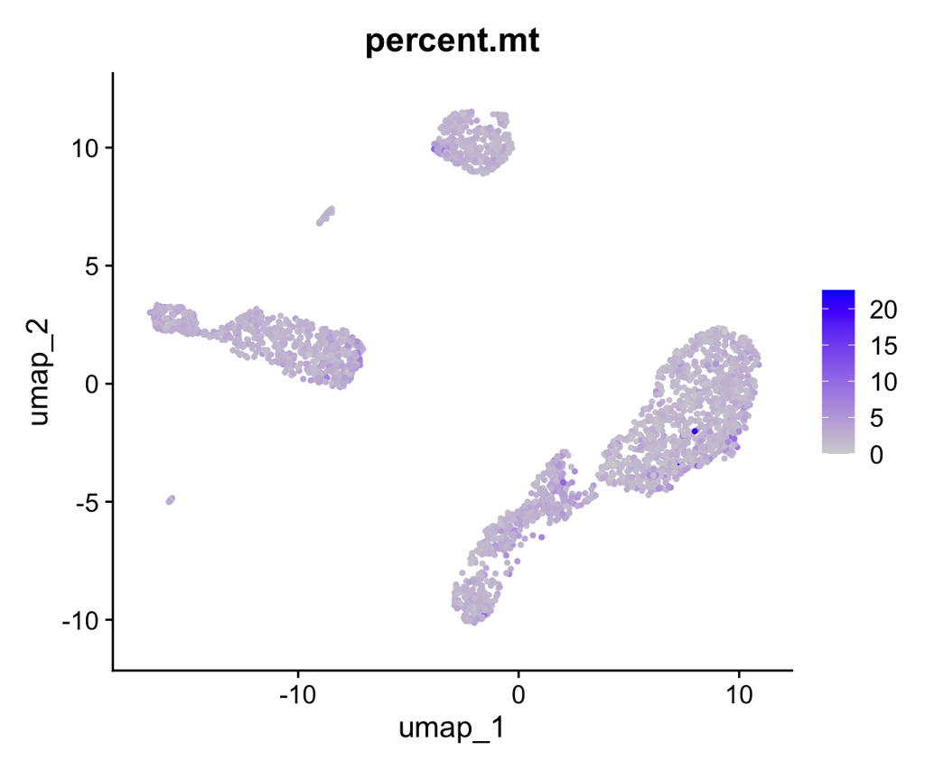

```r
Seurat::FeaturePlot(pbmc_sct,
                    features = "percent.mt",
                    reduction = "umap")
```

What you want here is a **boring** plot — uniformly pale, no region systematically darker. That is what this is. Had we skipped `vars.to.regress` and a corner of the embedding lit up, that corner would be a dying-cell cluster, and any cell type you named from it would be an artifact of tissue quality.

`scCustomize` provides a drop-in replacement with a better default colour scale; the pale-on-pale rendering above is exactly the case where it helps, because Seurat’s default scale wastes most of its range on the empty top end.

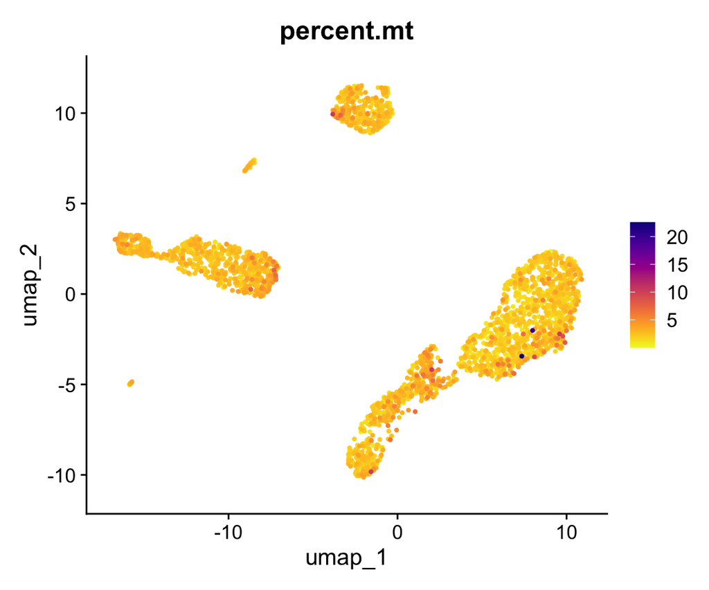

```r
scCustomize::FeaturePlot_scCustom(pbmc_sct,
                                  features = "percent.mt",
                                  reduction = "umap")
```

Now the top variable genes, which should mark distinct regions if the gene selection did its job:

```r
top_genes <- Seurat::VariableFeatures(pbmc_sct)[1:4]
top_genes
```

```
## [1] "S100A9" "GNLY"   "LYZ"    "S100A8"
```

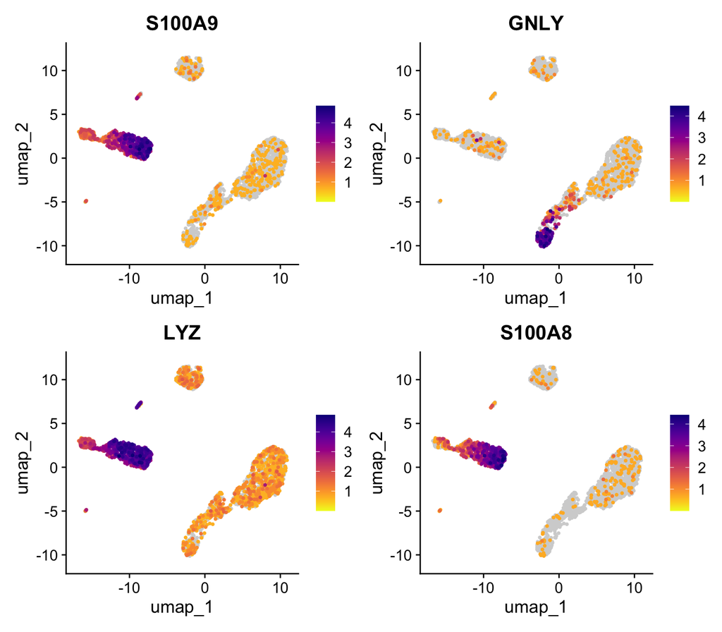

```r
scCustomize::FeaturePlot_scCustom(pbmc_sct,
                                  features = top_genes,
                                  reduction = "umap")
```

And the curated labels, for comparison:

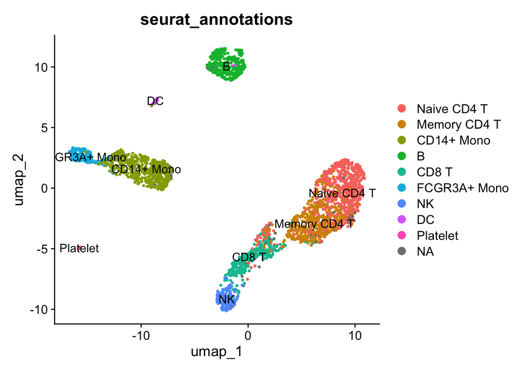

```r
Seurat::DimPlot(pbmc_sct, group.by = "seurat_annotations", label = TRUE)
```

# 7 Which genes got picked, and why not the loudest ones

This is the part of the tutorial that is about *gene selection* rather than normalization, and it is worth the detour, because “which 3,000 genes” is a decision with more downstream consequence than most people give it.

```r
count_mat <- SeuratObject::LayerData(pbmc, assay = "RNA", layer = "counts")

count_nonzero <- Matrix::rowSums(count_mat > 0)
pct_nonzero <- (count_nonzero / ncol(count_mat)) * 100
total_count <- Matrix::rowSums(count_mat)
avg_in_nonzero <- total_count / count_nonzero

variable_genes <- Seurat::VariableFeatures(pbmc_sct)
table(variable_genes %in% rownames(count_mat))
```

```
##
## TRUE
## 3000
```

`avg_in_nonzero` is average expression **among the cells that detected the gene**, which is a different question from average expression overall and keeps rare-but-strong markers from being flattened by the thousands of zeros around them.

> **A division waiting to fail.** `total_count / count_nonzero` is `0/0` for any gene detected in no cell, giving `NaN` and a silently missing point. pbmc3k has no such genes, so it does not bite here — but a matrix you subset yourself almost certainly will. `sum(count_nonzero == 0)` before dividing.

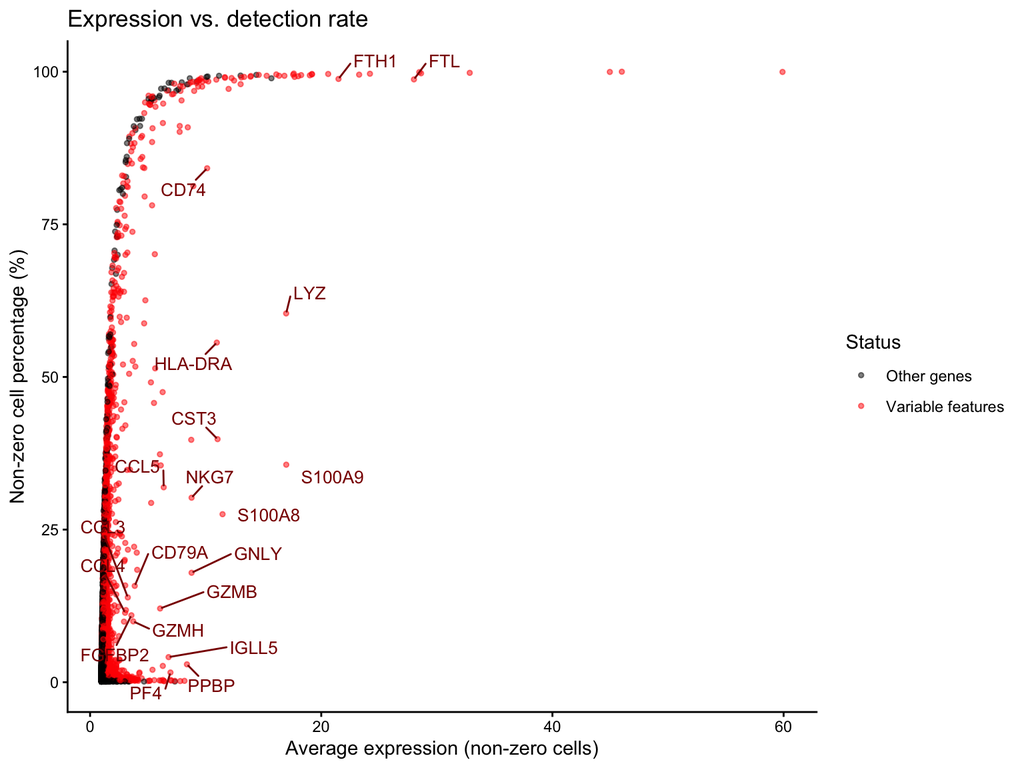

```r
detection_df <- data.frame(gene = rownames(count_mat),
                           avg_expression = avg_in_nonzero,
                           pct_nonzero = pct_nonzero,
                           is_variable = rownames(count_mat) %in%
                             variable_genes)

genes_to_label <- head(variable_genes, 20)

gg <- ggplot2::ggplot(detection_df,
                      ggplot2::aes(x = avg_expression, y = pct_nonzero,
                                   color = is_variable)) +
  ggplot2::geom_point(alpha = 0.5, size = 1) +
  ggplot2::scale_color_manual(values = c("FALSE" = "black", "TRUE" = "red"),
                              labels = c("Other genes", "Variable features"),
                              name = "Status") +
  ggrepel::geom_text_repel(data = subset(detection_df,
                                         gene %in% genes_to_label),
                           ggplot2::aes(label = gene),
                           color = "darkred",
                           size = 3.5,
                           max.overlaps = Inf,
                           box.padding = 0.5) +
  ggplot2::labs(x = "Average expression (non-zero cells)",
                y = "Non-zero cell percentage (%)",
                title = "Expression vs. detection rate") +
  ggplot2::theme_classic()
plot(gg)
```

The red points are not a corner of this plot. They are spread along both axes: `FTL` and `FTH1` sit at 99% detection, while `PF4` and `PPBP` — genuine platelet markers — are detected in under 3% of cells and are still selected. **Being selected is not the same as being abundant or being common.**

Most genes are crushed into the bottom-left corner, so zoom in:

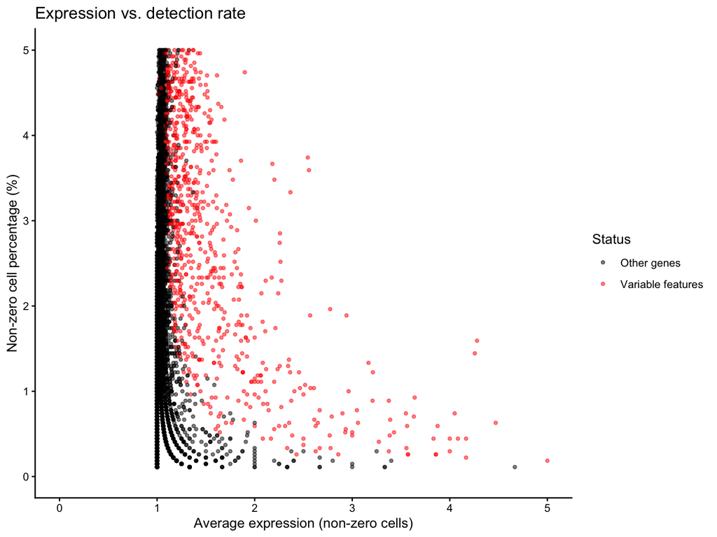

```r
gg_zoom <- gg + ggplot2::xlim(0, 5) + ggplot2::ylim(0, 5)
plot(gg_zoom)
```

This is where the great majority of genes live: detected in a few percent of cells, averaging one or two counts when they are. Not one of the twenty labelled genes falls inside this window, so the labels vanish entirely — which is itself the point. The genes that get selected are not in the crowd.

## 7.1 Mean versus variance

The classical way to pick variable genes is to look for genes whose variance exceeds what their mean would predict. Plotting the raw version shows why that needs the “exceeds what their mean would predict” clause.

```r
n <- ncol(count_mat)
row_means <- Matrix::rowMeans(count_mat)
row_vars <- (Matrix::rowSums(count_mat^2) - n * row_means^2) / (n - 1)

head(sort(row_vars, decreasing = TRUE), 10)
```

```
##       FTL      FTH1    MALAT1    TMSB4X       B2M       LYZ      ACTB     RPL10
## 2008.6889 1204.3175 1060.1824  952.8292  670.5365  564.1088  393.3969  320.6592
##     RPL13    RPL13A
##  289.2410  279.2000
```

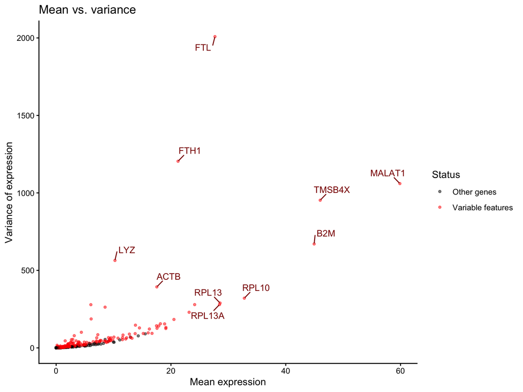

```r
variance_df <- data.frame(gene = rownames(count_mat),
                          mean = row_means,
                          variance = row_vars,
                          is_variable = rownames(count_mat) %in%
                            variable_genes)

genes_to_label <- names(sort(row_vars, decreasing = TRUE))[1:10]

gg <- ggplot2::ggplot(variance_df,
                      ggplot2::aes(x = mean, y = variance,
                                   color = is_variable)) +
  ggplot2::geom_point(alpha = 0.5, size = 1) +
  ggplot2::scale_color_manual(values = c("FALSE" = "black", "TRUE" = "red"),
                              labels = c("Other genes", "Variable features"),
                              name = "Status") +
  ggrepel::geom_text_repel(data = subset(variance_df,
                                         gene %in% genes_to_label),
                           ggplot2::aes(label = gene),
                           color = "darkred",
                           size = 3.5,
                           max.overlaps = Inf,
                           box.padding = 0.5) +
  ggplot2::labs(x = "Mean expression",
                y = "Variance of expression",
                title = "Mean vs. variance") +
  ggplot2::theme_classic()
plot(gg)
```

> **The bug this replaces.** An earlier version of this plot labelled its points with `subset(detection_df, ...)` — the data frame from the *previous* figure — while drawing the rest from `variance_df`. Because both frames have a `gene` column, `subset()` works and `geom_text_repel()` draws happily; the labels just land at coordinates taken from the wrong plot. Nothing errors. When a `geom_*()` gets its own `data =` argument, check that it is the frame the rest of the layer is using.

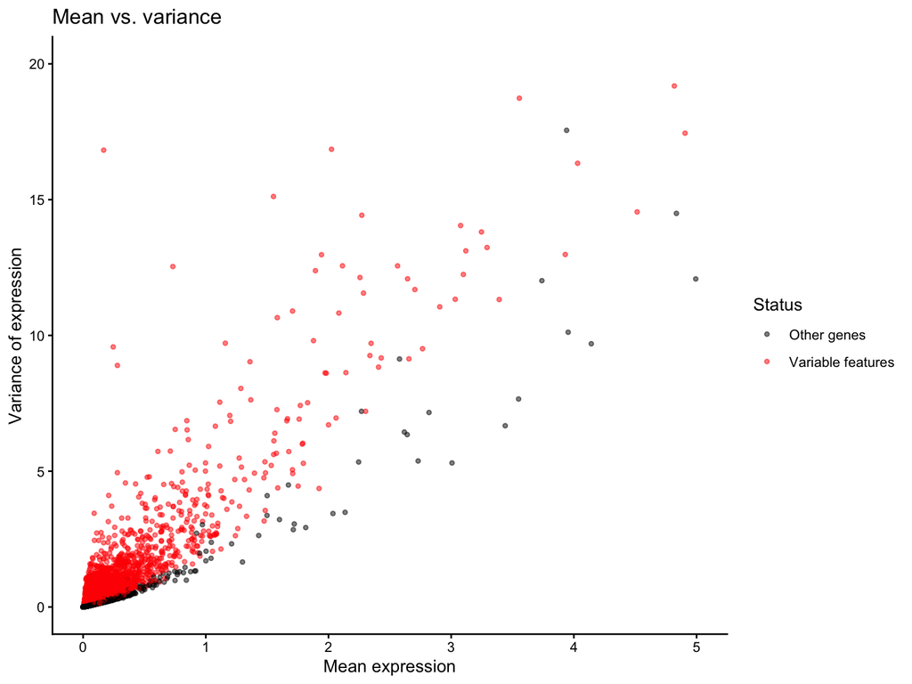

```r
gg_zoom <- gg + ggplot2::xlim(0, 5) + ggplot2::ylim(0, 20)
plot(gg_zoom)
```

Almost every gene falls inside this window, and now the structure is legible: variance rises with the mean along a clear lower edge, which is the counting noise floor. The black points hug that edge. The red points sit *above* it at every mean — more variable than genes of comparable abundance. That “above the trend at your abundance” is precisely what both the classical `vst` method and the SCT residual are trying to formalize.

## 7.2 How different is this from the Week 1 route?

Worth quantifying rather than asserting. Running the log-normalization route on the same data and asking for the same 3,000 genes:

```r
pbmc <- Seurat::FindVariableFeatures(pbmc,
                                     selection.method = "vst",
                                     nfeatures = 3000)
variable_genes_vst <- Seurat::VariableFeatures(pbmc)

length(intersect(variable_genes, variable_genes_vst))
```

```
## [1] 2039
```

```r
head(variable_genes_vst, 20)
```

```
##  [1] "PPBP"     "S100A9"   "IGLL5"    "LYZ"      "GNLY"     "FTL"
##  [7] "PF4"      "FTH1"     "FCER1A"   "GNG11"    "S100A8"   "HLA-DRA"
## [13] "CD74"     "CLU"      "GZMB"     "NKG7"     "C1QA"     "CST3"
## [19] "CCL4"     "HLA-DPB1"
```

**2,039 of 3,000 genes are shared** — so about a third of each list is unique to its method. The top of the two lists differs in a telling way: `vst` ranks `PPBP` first, a platelet gene detected in 2.9% of cells, driven by the 14 platelets in this sample. SCT ranks `S100A9` first, a monocyte gene detected in 36%.

Neither ranking is wrong. But if your downstream clustering is sensitive to the gene list — and it is — then “we used the default” is a choice you made, and a third of it would have been different under the other default.

# 8 Forcing specific genes in

Sometimes you need a gene set in the analysis whether or not it ranks: a pathway you are testing, a panel you validated, or — as here — the cell cycle genes, to check whether the regression removed them.

```r
cell_cycling <- intersect(c(s_genes, g2m_genes), SeuratObject::Features(pbmc))
length(cell_cycling)
```

```
## [1] 80
```

```r
table(cell_cycling %in% Seurat::VariableFeatures(pbmc_sct))
```

```
##
## FALSE  TRUE
##    67    13
```

Only 13 of the 80 made the list, which is the expected result: we regressed the cycle scores out, so cycle genes should have little residual variance left.

To override that, run `SCTransform()` again with the list you want and two extra arguments:

```r
highly_variable_genes <- unique(c(Seurat::VariableFeatures(pbmc_sct),
                                  cell_cycling))
length(highly_variable_genes)
```

```
## [1] 3067
```

```r
set.seed(10)
pbmc_final <- Seurat::SCTransform(pbmc,
                                  vars.to.regress = c("percent.mt",
                                                      "S.Score",
                                                      "G2M.Score"),
                                  residual.features = highly_variable_genes,
                                  variable.features.n = NULL,
                                  min_cells = 0,
                                  seed.use = 10,
                                  verbose = FALSE)
```

All three of those arguments are load-bearing, and leaving any one out fails quietly rather than loudly:

- **`residual.features`** is the list itself: the genes to compute Pearson residuals for.
- **`variable.features.n = NULL`** removes the cap. Left at its default of 3,000, Seurat re-ranks *your* genes by residual variance and keeps only the top 3,000, dropping the tail of your list without comment.
- **`min_cells = 0`** disables the detection filter — the same one that quietly removed 1,142 genes earlier. It defaults to 5, and six of the cell cycle genes are detected in fewer cells than that, so without this they never reach the model at all.

```r
length(Seurat::VariableFeatures(pbmc_final))
```

```
## [1] 3067
```

```r
table(cell_cycling %in% Seurat::VariableFeatures(pbmc_final))
```

```
##
## TRUE
##   80
```

3,067 genes requested, 3,067 returned, and all 80 cell cycle genes are in the list. `RunPCA()` reads `VariableFeatures()` by default, so they are in the principal components too.

> **`min_cells = 0` is a deliberate trade, not a free win.** A gene detected in three cells still gets a model fitted and a residual computed, and that residual is mostly noise. Turning the filter off is right when you need a specific gene set represented; it is a poor global default.

> **You may not need any of this.** `FeaturePlot()` and `AddModuleScore()` read the `data` layer, which covers every gene in the assay. Reach for `residual.features` only when the genes have to influence the *embedding*.

# 9 What we glossed over

- **`vst` versus SCT was compared by overlap, not by outcome.** We showed the lists differ by a third and stopped. The question that matters — do the clusters differ, and does any conclusion change — needs the clustering that is **Week 4** material.
- **`variable.features.n = 3000` is still a magic number.** SCTransform offers `variable.features.rv.th`, a residual-variance *threshold*, which lets the data decide how many genes qualify instead of fixing the count in advance.
- **We regressed cell cycle scores we had just shown were noise.** Faithful to the vignette, wrong for this dataset, and something to actively avoid on brain data. See the callout above.
- **`dims = 1:8` came from eyeballing an elbow.** `ElbowPlot()` and `JackStraw()` formalize it a little; nothing formalizes it completely, and the honest check is whether your conclusions survive 10 and 20 dimensions.
- **Regressing a covariate out is not the only option.** It can remove real biology that happens to correlate with the covariate. Keeping `percent.mt` as a covariate in a differential expression model — rather than deleting it from the data — is often more defensible. **Week 4**.
- **`min_cells` dropped 1,142 genes without comment**, and we only noticed by comparing two dimensions. If a specific gene matters to you, confirm it survived.
- **SCT and multi-sample data.** With several batches, `SCTransform()` should see them together and `IntegrateLayers()` should be told `normalization.method = "SCT"`. The companion Week 3 integration tutorial takes the log-normalization route instead; combining the two is a one-argument change.

# 10 References

- Hafemeister C, Satija R. *Normalization and variance stabilization of single-cell RNA-seq data using regularized negative binomial regression.* Genome Biology 20:296, 2019. [doi:10.1186/s13059-019-1874-1](https://doi.org/10.1186/s13059-019-1874-1)
- Choudhary S, Satija R. *Comparison and evaluation of statistical error models for scRNA-seq.* Genome Biology 23:27, 2022. [doi:10.1186/s13059-021-02584-9](https://doi.org/10.1186/s13059-021-02584-9) — the follow-up on when Pearson residuals help and when they do not.
- Tirosh I, Izar B, Prakadan SM, *et al.* *Dissecting the multicellular ecosystem of metastatic melanoma by single-cell RNA-seq.* Science 352:189–196, 2016 — the source of `cc.genes`.
- Seurat vignettes: [SCTransform](https://satijalab.org/seurat/articles/sctransform_vignette), [Cell cycle scoring](https://satijalab.org/seurat/articles/cell_cycle_vignette.html)